# <i class="fas fa-boxes"></i> Conceptual diagram

See [Boulangeat, 2014](papers/Boulangeat_2014_Global_Change_Biology.pdf “Boulangeat, I., Georges, D., Thuiller, W., FATE-HD: A spatially and temporally explicit integrated model for predicting vegetation structure and diversity at regional scale. Global Change Biology, 20, 2368–2378.”) or the [Publications](fate_tutorial_0_publications.html) page

## Conceptual diagram

The whole area is divided in grid-cells in which an independent **demographic model** regulates the PFG life cycle. PFG abundances are structured by age into cohorts and each cohort is attributed to a height stratum according to the growth parameters.

Different submodels affect this cycle at various levels :

- **Competition through light and/or soil resources** regulates interactions between cohorts affecting germination, recruitment and survival.
- **Habitat suitability** affects the recruitment and fecundity rates.
- **The seed dispersal model** makes `FATE` spatially explicit by connecting grid-cells.  
  It depends on the amount of seeds produced by mature plants and affects each PFG’s seed bank in each cell.
- **Disturbances** affect PFG survival and fecundity.

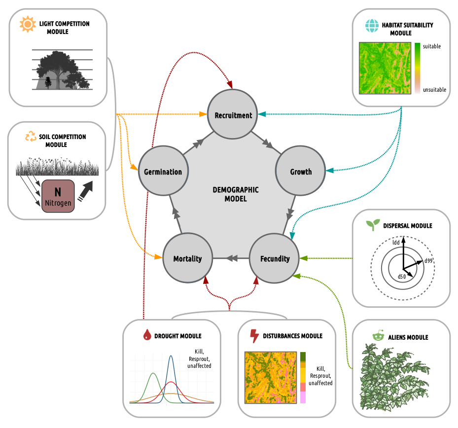

## Life cycle of each PFG and influences from sub-models

Only three age classes are considered : **germinant**, **juvenile** and **mature**.

- The **recruitment** is influenced by the habitat suitability and the biotic interactions.
- **Mortality** occurs when light or soil conditions are not favorable or when the PFG completes its life span.
- In addition, the disturbance regime directly affects juvenile or mature PFG and may for instance result in PFG death, impede **seed production** by reducing mature PFG age to N-1, or **revitalize senescents** by reducing their age to M-1.

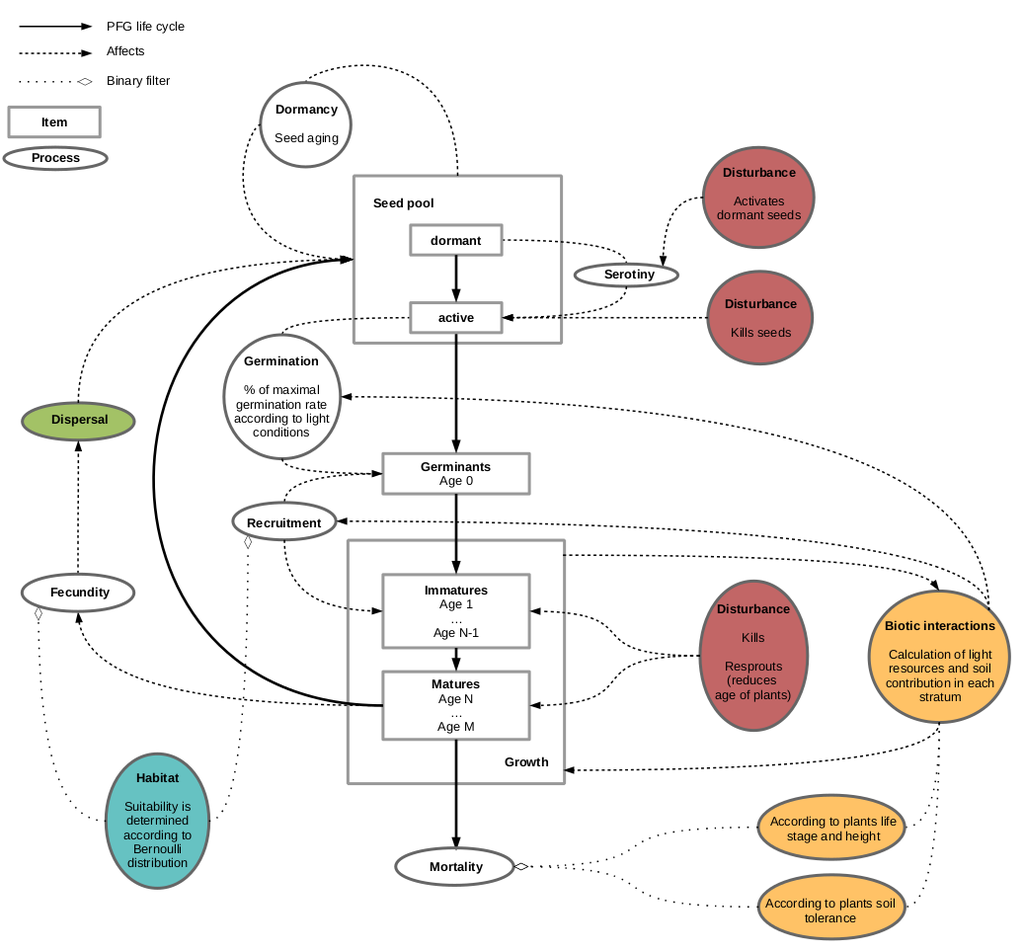

The timestep is at the year level : seasonality is not included within each timestep, but communities go through 4 states :

1. **Check of survival** : what are the pixel resources (in terms of light and soil) of the previous year, and can the PFG stand them ?
2. All PFG **grow one-year older**, and too old PFG die.
3. **New pixel resources** (in terms of light and soil) are calculated with the actual community, as well as the **seeds produced**. **Recruitment** of new individuals from the previous pool of seeds occurs.
4. If some perturbations are defined, community is impacted in function of the **PFG responses to the disturbance(s)**.

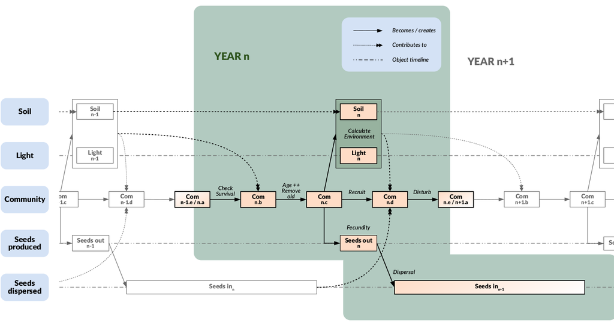